# Data analysis of developer responses

# Load data

```r
data <- read.csv( file = "./clus_data.csv", stringsAsFactors = FALSE )
clus_data <- read.csv("clus_data.csv")
clus_data <- data.frame(clus_data)
numericColumns <- sapply(data, is.numeric)
cols <- c(7:20, 26:35, 37:42) # Selecting the numerical columns
clus_data_selected <- clus_data[, cols]
str(clus_data_selected)
```

```
## 'data.frame':    130 obs. of  30 variables:
##  $ INVA   : int  2 2 3 3 1 4 5 1 2 3 ...
##  $ INVB   : int  NA 4 4 4 1 NA 5 5 4 5 ...
##  $ INVC   : int  4 2 3 3 1 NA 4 2 3 2 ...
##  $ INVD   : int  NA 2 3 3 1 NA 5 2 2 4 ...
##  $ INVE   : int  NA 4 3 3 5 NA 1 4 4 3 ...
##  $ INVF   : int  4 2 4 4 1 NA 4 3 3 4 ...
##  $ INVG   : int  2 2 1 2 5 NA 5 1 1 1 ...
##  $ INVH   : int  NA 4 2 3 5 NA 1 1 2 3 ...
##  $ INVI   : int  NA 4 2 4 5 NA 2 4 3 2 ...
##  $ INVJ   : int  2 5 2 1 2 NA 1 1 1 2 ...
##  $ INVK   : int  NA NA NA 3 4 NA 2 1 1 2 ...
##  $ INVL   : int  NA NA NA 3 5 NA 4 1 4 4 ...
##  $ INVM   : int  3 2 NA 2 4 NA 3 3 3 2 ...
##  $ INVN   : int  NA 2 NA 2 3 NA 2 2 3 3 ...
```

[output cut: 16 more lines]

```r
# and a scaled version of that with NA's removed
clus_data_scaled <- scale(na.omit(clus_data_selected))
```

```r
summary(as.data.frame(unclass(data)))
```

```
##        X                   SUBTIME       JOBFUNC
##  Min.   :  1.00   19.4.17 12:54:  2   Min.   : 0.000
##  1st Qu.: 33.25   19.4.17 12:55:  2   1st Qu.: 0.000
##  Median : 65.50   27.3.17 15:05:  2   Median : 1.000
##  Mean   : 65.50   27.3.17 15:07:  2   Mean   : 2.162
##  3rd Qu.: 97.75   27.3.17 15:34:  2   3rd Qu.: 3.750
##  Max.   :130.00   10.3.17 12:56:  1   Max.   :10.000
##                   (Other)      :119
##                    JOBFUNCOTHER    JOBTIME        GENDER
##                          :109   Min.   :   2.0   F   : 12
##  Account Manager         :  1   1st Qu.:  12.0   M   :111
##  Customer Service Manager:  1   Median :  36.0   NA's:  7
##  Customer Support        :  1   Mean   : 650.9
##  Office administration   :  1   3rd Qu.:  60.0
##  (Other)                 :  9   Max.   :9999.0
##  NA's                    :  8
##       INVA            INVB            INVC           INVD
##  Min.   :1.000   Min.   :1.000   Min.   :1.00   Min.   :1.000
##  1st Qu.:2.000   1st Qu.:4.000   1st Qu.:2.00   1st Qu.:2.000
##  Median :2.000   Median :5.000   Median :2.00   Median :3.000
##  Mean   :2.539   Mean   :4.508   Mean   :2.48   Mean   :2.697
##  3rd Qu.:3.000   3rd Qu.:5.000   3rd Qu.:3.00   3rd Qu.:3.000
##  Max.   :5.000   Max.   :5.000   Max.   :5.00   Max.   :5.000
##  NA's   :2       NA's   :4       NA's   :5      NA's   :8
##       INVE            INVF            INVG            INVH
##  Min.   :1.000   Min.   :1.000   Min.   :1.000   Min.   :1.000
##  1st Qu.:2.000   1st Qu.:3.000   1st Qu.:2.000   1st Qu.:2.000
##  Median :3.000   Median :4.000   Median :2.000   Median :3.000
##  Mean   :3.127   Mean   :3.427   Mean   :2.526   Mean   :2.925
##  3rd Qu.:4.000   3rd Qu.:4.000   3rd Qu.:3.000   3rd Qu.:4.000
##  Max.   :5.000   Max.   :5.000   Max.   :5.000   Max.   :5.000
##  NA's   :4       NA's   :6       NA's   :14      NA's   :10
##       INVI            INVJ            INVK            INVL
##  Min.   :1.000   Min.   :1.000   Min.   :1.000   Min.   :1.000
##  1st Qu.:3.000   1st Qu.:2.000   1st Qu.:2.000   1st Qu.:2.000
##  Median :4.000   Median :2.000   Median :2.000   Median :3.000
##  Mean   :3.439   Mean   :2.535   Mean   :2.311   Mean   :3.106
##  3rd Qu.:4.000   3rd Qu.:3.000   3rd Qu.:3.000   3rd Qu.:4.000
##  Max.   :5.000   Max.   :5.000   Max.   :4.000   Max.   :5.000
##  NA's   :7       NA's   :16      NA's   :27      NA's   :17
```

[output cut: 33 more lines]

```
##  Never        : 6   Min.   :1.000   Min.   :1.000   Min.   :1.000
##  Occasionally :41   1st Qu.:3.000   1st Qu.:2.000   1st Qu.:4.000
##  Rarely       :10   Median :4.000   Median :3.000   Median :4.000
##  Yes, actively:58   Mean   :3.433   Mean   :3.276   Mean   :3.922
##  NA's         :15   3rd Qu.:4.000   3rd Qu.:4.000   3rd Qu.:4.000
##                     Max.   :5.000   Max.   :5.000   Max.   :5.000
##                     NA's   :3       NA's   :3       NA's   :1
##      X3.3D           X3.3E           X3.3F           COMPANY
##  Min.   :1.000   Min.   :1.000   Min.   :1.000   Ericsson:35
##  1st Qu.:4.000   1st Qu.:3.000   1st Qu.:3.000   F-secure: 8
##  Median :4.000   Median :4.000   Median :4.000   Reaktor :66
##  Mean   :3.984   Mean   :3.667   Mean   :3.738   Vaadin  :21
##  3rd Qu.:5.000   3rd Qu.:4.000   3rd Qu.:4.000
##  Max.   :5.000   Max.   :5.000   Max.   :5.000
##  NA's   :1       NA's   :1
```

## Removing/marking outliers

The column JOBTIME has the values 9999 that would mess up some of the plots and statistics below.

```r
sum( data$JOBTIME > 200 , na.rm=T)
```

```
## [1] 8
```

Turn values that too large into NA’s.

```r
data$JOBTIME <- ifelse( data$JOBTIME > 200, NA, data$JOBTIME)
```

# Mosaic plots

It is a good idea to visualize the conditional probabilities between different columns.

## Role vs gender

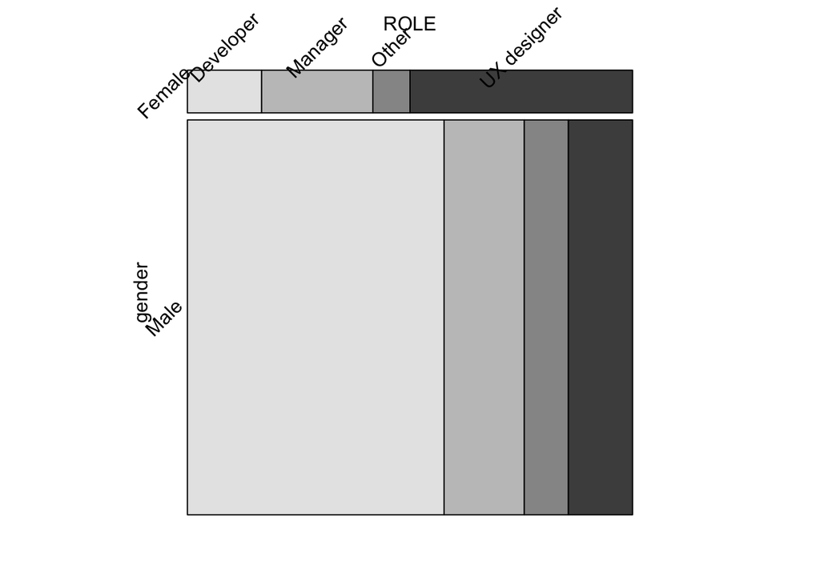

```r
mosaic( ROLE ~ gender, data = data, color=2:3, rot_labels=c(45,45,45,45)  )
```

In the plot above we can see that the interviewed females are much more likely to be UX designers and managers than developers.

## Other trials

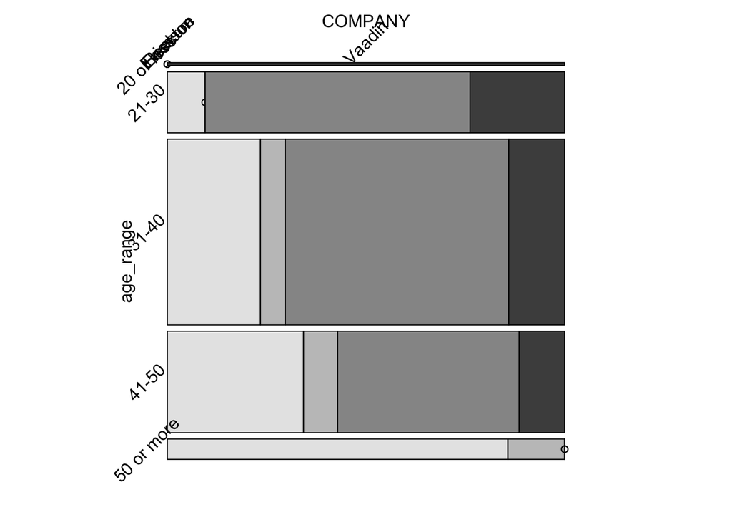

```r
mosaic( COMPANY ~ age_range, data = data, color=2:3, rot_labels=c(45,45,45,45)  )
```

## Role vs age

From the plots in this sub-section we can see:

- that there are no (interviewed) managers between 21-30;
- people older than 50 are much less likely to work in the industry (or answer interview questions);
- people older than 50 are much more likely to be managers, compared to the other age groups.

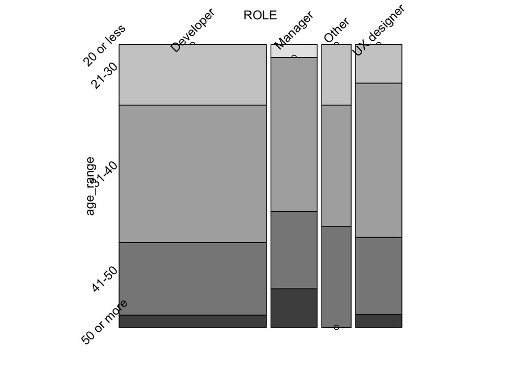

```r
mosaic( age_range ~ ROLE, data, direction = "v", rot_labels=c(45,45,45,45) )
```

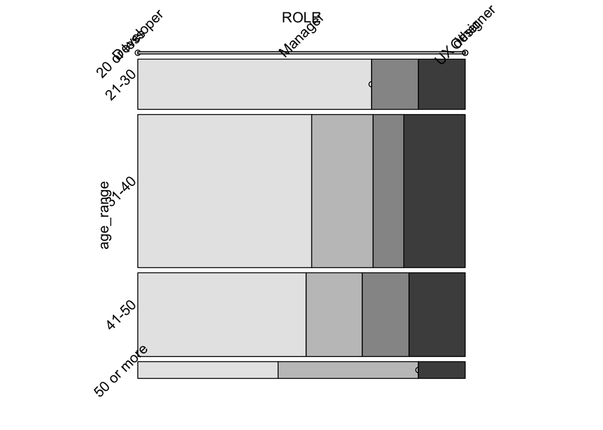

```r
mosaic( ROLE ~ age_range, data, rot_labels=c(45,45,45,45) )
```

# Clustering

Using hierarchical clustering and visualizing with a heat-map.

```r
#inv <- clus_data_selected[, 15:20]
#class(inv)
d3heatmap( clus_data_selected, Rowv = TRUE, Colv = FALSE, scale = "column", na.rm = TRUE, dendrogram = "row", k_row = 4)
```

[interactive chart not shown]

### Correlations benween coliumns

Correlations for all numerical columns:

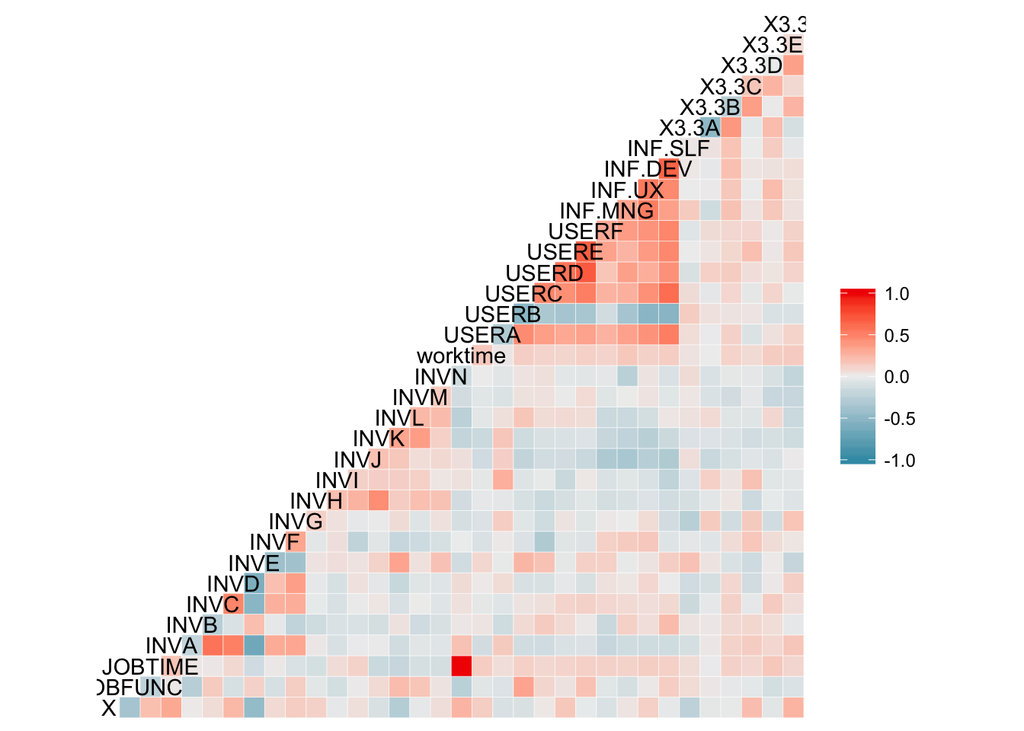

```r
qData <- data[, grepl("INV",colnames(data)) & numericColumns ]
qData <- data[, numericColumns ]
#qData <- qData[ rowSums( is.na(qData) ) < 6, ]
GGally::ggcorr( qData, method = c("pairwise","spearman") )
```

It is a good idea to explain the correlations that are close to 1 and -1. Do they make sense, etc.

Correlations for selected numerical columns:

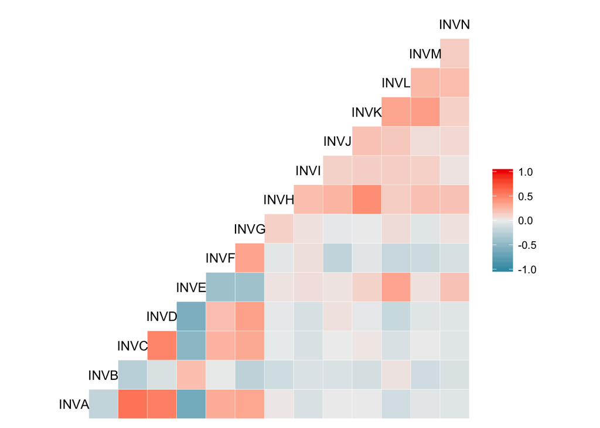

```r
# Numerical columns starting with "INV".
qData <- data[, grepl("^INV",colnames(data)) & numericColumns ]
# Removing rows that have too many NA's.
qData <- qData[ rowSums( is.na(qData) ) < 6, ]
GGally::ggcorr( qData, method = c("pairwise","spearman") )
```